# 🛒 Olist E-Commerce

## Segmentación por: Clientes · Vendedores · Productos

Un estudio de segmentación basado en datos del marketplace de e-commerce más grande de Brasil — descubriendo quién compra, quién vende y qué se mueve.

96K  
Ordenes

3K  
Vendedores

32K  
Productos

2016–2018  
Periodo

```python
import pandas as pd
import numpy as np
import matplotlib.pyplot as plt
import matplotlib.patches as mpatches
import matplotlib.gridspec as gridspec
import warnings
warnings.filterwarnings('ignore')

# ── Dark theme setup ───────────────────────────────────────────────────────
plt.rcParams.update({
    'figure.facecolor':  '#0f0f1a',
    'axes.facecolor':    '#1a1a2e',
    'axes.edgecolor':    '#2d2d4e',
    'axes.labelcolor':   '#94a3b8',
    'axes.titlecolor':   '#e2e8f0',
    'xtick.color':       '#64748b',
    'ytick.color':       '#64748b',
    'text.color':        '#e2e8f0',
    'grid.color':        '#2d2d4e',
    'grid.linewidth':    0.8,
    'figure.dpi':        130,
    'axes.spines.top':   False,
    'axes.spines.right': False,
    'font.size':         11,
})

# ── Color palette ──────────────────────────────────────────────────────────
BLUE    = '#38bdf8'
PURPLE  = '#a78bfa'
GREEN   = '#34d399'
ORANGE  = '#fb923c'
PINK    = '#f472b6'
YELLOW  = '#fbbf24'
COLORS  = [BLUE, PURPLE, GREEN, ORANGE]

# Cargamos cvs de resultados del analisis
customers = pd.read_csv('results/customer_clusters.csv')
sellers   = pd.read_csv('results/seller_clusters.csv')
products  = pd.read_csv('results/product_clusters.csv')

print('✅ Data loaded')
print(f'   Customers: {len(customers):,}')
print(f'   Sellers:   {len(sellers):,}')
print(f'   Products:  {len(products):,}')
```

```
✅ Data loaded
   Customers: 96,469
   Sellers:   2,970
   Products:  32,214
```

## 📦 Sección 1 — Acerca de Olist & Los Datos

Olist es una plataforma de e-commerce brasileña que conecta pequeños y medianos vendedores con los principales marketplaces. Este análisis cubre 2 años de transacciones distribuidas en 8 datasets interconectados.

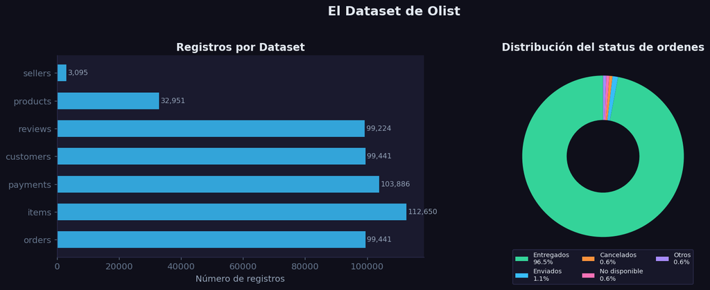

```python
# Dataset overview
datasets = {
    'orders':    99441,
    'items':     112650,
    'payments':  103886,
    'customers': 99441,
    'reviews':   99224,
    'products':  32951,
    'sellers':   3095,
    'geolocation': 1000163,
}

fig, axes = plt.subplots(1, 2, figsize=(14, 5)) # Dos graficas lado (1 fila, 2 columnas, tamaño)
fig.suptitle('El Dataset de Olist ', fontsize=16, fontweight='bold', color='#e2e8f0', y=1.02)

# Grafica de barras se ignora geolocation, largo y no llegamos a usarla
ds_plot = {k: v for k, v in datasets.items() if k != 'geolocation'}
bars = axes[0].barh(list(ds_plot.keys()), list(ds_plot.values()), # axes[0] es la primera grafica
                    color=BLUE, alpha=0.85, height=0.6)
axes[0].set_title('Registros por Dataset', fontweight='bold')
axes[0].set_xlabel('Número de registros')
for bar, val in zip(bars, ds_plot.values()):
    axes[0].text(val + 500, bar.get_y() + bar.get_height()/2,
                f'{val:,}', va='center', fontsize=9, color='#94a3b8')

# Dona estado de las ordenes
status_data  = [96478, 1107, 625, 609, 622]
status_labels = ['Entregados\n96.5%', 'Enviados\n1.1%', 'Cancelados\n0.6%',
                 'No disponible\n0.6%', 'Otros\n0.6%']
status_colors = [GREEN, BLUE, ORANGE, PINK, PURPLE]
wedges, _ = axes[1].pie(status_data, colors=status_colors,
                         startangle=90, wedgeprops=dict(width=0.55)) #axes[1] es la segunda grafica
axes[1].set_title('Distribución del status de ordenes', fontweight='bold')
axes[1].legend(wedges, status_labels, loc='lower center',
               bbox_to_anchor=(0.5, -0.15), ncol=3, fontsize=8,
               facecolor='#1a1a2e', edgecolor='#2d2d4e')

plt.tight_layout()
plt.savefig('results/fig_dataset_overview.png', dpi=150, bbox_inches='tight',
            facecolor='#0f0f1a') #guardamos la grafica para el futuro
plt.show()
```

## 👥 Sección 2 — Segmentación de Clientes

K-Means clustering (K=4) a 96,469 clientes usando gasto, medio de pago, frecuencia, satisfacción y experiencia de entrega. Silhouette score: **0.34**

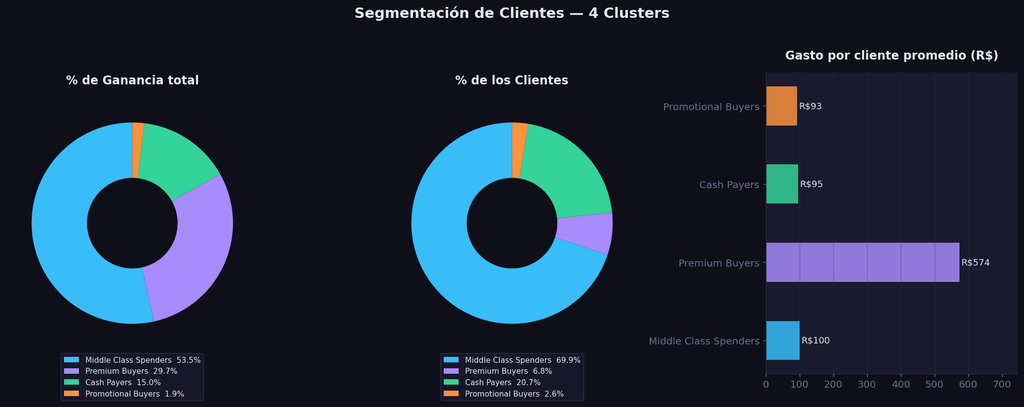

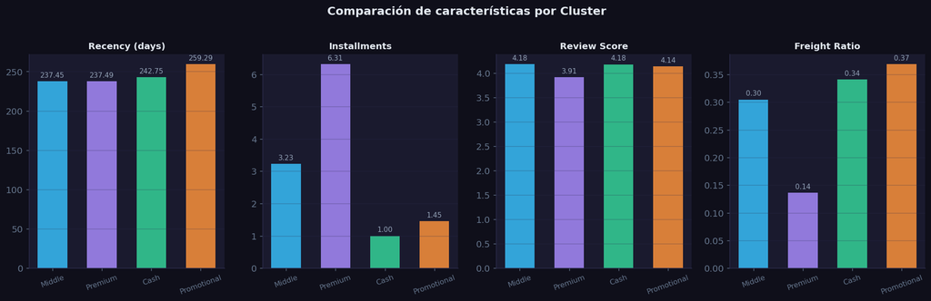

```python
# ── Desglose de los clusters de clientes
cust_summary = customers.groupby('cluster_name')['total_price'].agg(
    ['sum','mean','count']).round(2)
cust_summary['pct_customers'] = (cust_summary['count'] / cust_summary['count'].sum() * 100).round(1)
cust_summary['pct_revenue']   = (cust_summary['sum']   / cust_summary['sum'].sum()   * 100).round(1)
cust_summary = cust_summary.sort_values('pct_revenue', ascending=False)

cluster_order  = cust_summary.index.tolist()
cust_colors    = [BLUE, PURPLE, GREEN, ORANGE]
color_map_cust = dict(zip(cluster_order, cust_colors))

#  Grafica 1: Dona + gasto promedio
fig1, axes1 = plt.subplots(1, 3, figsize=(16, 6))
fig1.suptitle('Segmentación de Clientes — 4 Clusters', fontsize=16,
              fontweight='bold', color='#e2e8f0', y=1.02)

wedges, _ = axes1[0].pie(
    cust_summary['pct_revenue'],
    colors=[color_map_cust[c] for c in cluster_order],
    startangle=90, wedgeprops=dict(width=0.55)
)
axes1[0].set_title('% de Ganancia total', fontweight='bold', pad=15)
axes1[0].legend(wedges,
                [f'{c}  {v:.1f}%' for c, v in zip(cluster_order, cust_summary['pct_revenue'])],
                loc='lower center', bbox_to_anchor=(0.5, -0.22),
                fontsize=8.5, facecolor='#1a1a2e', edgecolor='#2d2d4e')
# segunda dona
wedges2, _ = axes1[1].pie(
    cust_summary['pct_customers'],
    colors=[color_map_cust[c] for c in cluster_order],
    startangle=90, wedgeprops=dict(width=0.55)
)
axes1[1].set_title('% de los Clientes', fontweight='bold', pad=15)
axes1[1].legend(wedges2,
                [f'{c}  {v:.1f}%' for c, v in zip(cluster_order, cust_summary['pct_customers'])],
                loc='lower center', bbox_to_anchor=(0.5, -0.22),
                fontsize=8.5, facecolor='#1a1a2e', edgecolor='#2d2d4e')
# Barras gasto promedio por cliente
bars = axes1[2].barh(cluster_order, cust_summary['mean'],
                     color=[color_map_cust[c] for c in cluster_order],
                     height=0.5, alpha=0.85)
axes1[2].set_title('Gasto por cliente promedio (R$)', fontweight='bold', pad=15)
for bar, val in zip(bars, cust_summary['mean']):
    axes1[2].text(val + 5, bar.get_y() + bar.get_height()/2,
                  f'R${val:,.0f}', va='center', fontsize=10, color='#e2e8f0')
axes1[2].set_xlim(0, cust_summary['mean'].max() * 1.3)
axes1[2].xaxis.grid(True, alpha=0.3)

plt.tight_layout()
plt.savefig('results/fig_customer_clusters.png', dpi=150, bbox_inches='tight',
            facecolor='#0f0f1a')
plt.show()

#  Grafica 2 Comparacion de caracteristicas
features_to_show = ['recency_days', 'installments', 'review_score', 'freight_ratio']
feature_labels   = ['Recency (days)', 'Installments', 'Review Score', 'Freight Ratio']

fig2, axes2 = plt.subplots(1, 4, figsize=(16, 5))
fig2.suptitle('Comparación de características por Cluster', fontsize=14,
              fontweight='bold', color='#e2e8f0', y=1.02)

for idx, (feat, label) in enumerate(zip(features_to_show, feature_labels)):
    if feat in customers.columns:
        vals = customers.groupby('cluster_name')[feat].mean()[cluster_order]
        axes2[idx].bar(range(len(cluster_order)), vals,
                       color=[color_map_cust[c] for c in cluster_order],
                       alpha=0.85, width=0.6)
        axes2[idx].set_title(label, fontweight='bold', fontsize=11)
        axes2[idx].set_xticks(range(len(cluster_order)))
        axes2[idx].set_xticklabels([c.split()[0] for c in cluster_order],
                                    rotation=20, fontsize=9)
        axes2[idx].yaxis.grid(True, alpha=0.3)
        for j, val in enumerate(vals):
            axes2[idx].text(j, val + vals.max() * 0.02,
                            f'{val:.2f}', ha='center', fontsize=8.5, color='#94a3b8')

plt.tight_layout()
plt.savefig('results/fig_customer_cluster_features.png', dpi=150, bbox_inches='tight',
            facecolor='#0f0f1a')
plt.show()
```

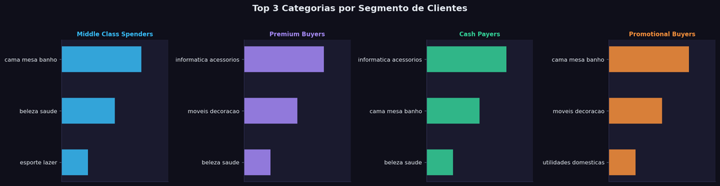

```python
# Grafica 3: Top categorias por cluster
fig3, axes3 = plt.subplots(1, 4, figsize=(16, 4))
fig3.suptitle('Top 3 Categorias por Segmento de Clientes', fontsize=14,
              fontweight='bold', color='#e2e8f0', y=1.02)
# Diccionario de categorias por cluster
cat_data = {
    'Middle Class Spenders': ['cama_mesa_banho', 'beleza_saude', 'esporte_lazer'],
    'Premium Buyers':        ['informatica_acessorios', 'moveis_decoracao', 'beleza_saude'],
    'Cash Payers':           ['informatica_acessorios', 'cama_mesa_banho', 'beleza_saude'],
    'Promotional Buyers':    ['cama_mesa_banho', 'moveis_decoracao', 'utilidades_domesticas'],
}
# grafica
for idx, (cluster, cats) in enumerate(cat_data.items()):
    color = list(color_map_cust.values())[idx]
    clean_cats = [c.replace('_', ' ') for c in cats]
    axes3[idx].barh(clean_cats[::-1], [1, 2, 3],
                    color=color, alpha=0.85, height=0.5)
    axes3[idx].set_title(cluster, fontweight='bold', fontsize=9.5, color=color)
    axes3[idx].set_xlim(0, 4)
    axes3[idx].set_xticks([])
    axes3[idx].tick_params(axis='y', labelsize=9, labelcolor='#e2e8f0')

plt.tight_layout()
plt.savefig('results/fig_topcategories_customer_clusters.png', dpi=150, bbox_inches='tight',
            facecolor='#0f0f1a')
plt.show()
```

```python
# Resumen
print('\n📊 RESUMEN DE CLUSTERS DE CLIENTES')
print('=' * 75)
display_df = cust_summary[['count', 'pct_customers', 'sum', 'pct_revenue', 'mean']].copy()
display_df.columns = ['# Clientes', '% Clientes', 'Ingresos Totales (R$)', '% Ingresos', 'Gasto Promedio (R$)']
display_df['Ingresos Totales (R$)'] = display_df['Ingresos Totales (R$)'].map('R${:,.0f}'.format)
display_df['Gasto Promedio (R$)']     = display_df['Gasto Promedio (R$)'].map('R${:,.0f}'.format)
display_df['# Clientes']       = display_df['# Clientes'].map('{:,.0f}'.format)
display_df['% Clientes']       = display_df['% Clientes'].map('{:.1f}%'.format)
display_df['% Ingresos']         = display_df['% Ingresos'].map('{:.1f}%'.format)
display_df.style.set_table_styles([
    {'selector': 'th', 'props': [('background-color', '#1a1a2e'), ('color', '#38bdf8'),
                                  ('font-weight', 'bold'), ('padding', '8px 12px')]},
    {'selector': 'td', 'props': [('background-color', '#0f0f1a'), ('color', '#e2e8f0'),
                                  ('padding', '8px 12px'), ('border-bottom', '1px solid #2d2d4e')]},
])
```

```
📊 RESUMEN DE CLUSTERS DE CLIENTES
===========================================================================
```

| cluster_name | # Clientes | % Clientes | Ingresos Totales (R$) | % Ingresos | Gasto Promedio (R$) |
| --- | --- | --- | --- | --- | --- |
| Middle Class Spenders | 67,437 | 69.9% | R$6,767,132 | 53.5% | R$100 |
| Premium Buyers | 6,538 | 6.8% | R$3,752,488 | 29.7% | R$574 |
| Cash Payers | 19,938 | 20.7% | R$1,894,594 | 15.0% | R$95 |
| Promotional Buyers | 2,556 | 2.6% | R$236,754 | 1.9% | R$93 |

### 💡 Insights de Clientes

[output not shown]

## 🏪 Section 3 — Seller Segmentation

K-Means clustering (K=3) a 2,970 vendedores usando volumen, ganancia, precio, reseñas, tiempos de entrega y competitividad de precios. Silhouette score: **0.57**

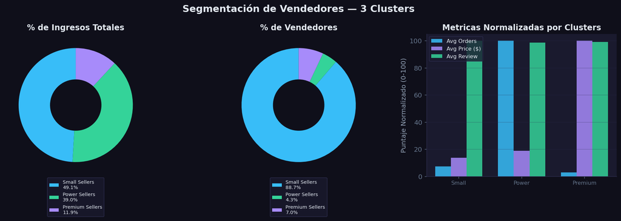

```
📊 SELLER CLUSTER SUMMARY
```

| cluster_name | # Vendedores | % Vendedores | Ingresos Totales (R$) | % Ingresos | Ing. Promedio (R$) | Órd. Promedio |
| --- | --- | --- | --- | --- | --- | --- |
| Small Sellers | 2,634 | 88.7% | R$5,607,813 | 49.1% | R$2,129 | 21 |
| Power Sellers | 127 | 4.3% | R$4,455,393 | 39.0% | R$35,082 | 291 |
| Premium Sellers | 209 | 7.0% | R$1,362,608 | 11.9% | R$6,520 | 8 |

```python
# Cluster de Vendedores
seller_names = {0: 'Premium Sellers', 1: 'Power Sellers', 2: 'Small Sellers'}
if 'cluster_name' not in sellers.columns:
    sellers['cluster_name'] = sellers['cluster'].map(seller_names)

sell_summary = sellers.groupby('cluster_name')['total_revenue'].agg(
    ['sum','mean','count']).round(2)
sell_summary['pct_sellers'] = (sell_summary['count'] / sell_summary['count'].sum() * 100).round(1)
sell_summary['pct_revenue'] = (sell_summary['sum']   / sell_summary['sum'].sum()   * 100).round(1)
sell_summary = sell_summary.sort_values('pct_revenue', ascending=False)

sell_order      = sell_summary.index.tolist()
sell_colors_map = {'Power Sellers': GREEN, 'Small Sellers': BLUE, 'Premium Sellers': PURPLE}

fig, axes = plt.subplots(1, 3, figsize=(15, 5))
fig.suptitle('Segmentación de Vendedores — 3 Clusters', fontsize=16,
             fontweight='bold', color='#e2e8f0')

# Dona Ingresos
wedges, _ = axes[0].pie(
    sell_summary['pct_revenue'],
    colors=[sell_colors_map[c] for c in sell_order],
    startangle=90, wedgeprops=dict(width=0.55)
)
axes[0].set_title('% de Ingresos Totales', fontweight='bold')
axes[0].legend(wedges,
               [f'{c}\n{v:.1f}%' for c, v in zip(sell_order, sell_summary['pct_revenue'])],
               loc='lower center', bbox_to_anchor=(0.5, -0.3),
               fontsize=8, facecolor='#1a1a2e', edgecolor='#2d2d4e')

# dona % vendedores
wedges2, _ = axes[1].pie(
    sell_summary['pct_sellers'],
    colors=[sell_colors_map[c] for c in sell_order],
    startangle=90, wedgeprops=dict(width=0.55)
)
axes[1].set_title('% de Vendedores', fontweight='bold')
axes[1].legend(wedges2,
               [f'{c}\n{v:.1f}%' for c, v in zip(sell_order, sell_summary['pct_sellers'])],
               loc='lower center', bbox_to_anchor=(0.5, -0.3),
               fontsize=8, facecolor='#1a1a2e', edgecolor='#2d2d4e')

# Comparacion
metrics = sellers.groupby('cluster_name')[['total_orders','avg_price','avg_review']].mean()
x = np.arange(len(sell_order))
width = 0.25
metric_cols   = ['total_orders', 'avg_price', 'avg_review']
metric_labels = ['Avg Orders', 'Avg Price ($)', 'Avg Review']
metric_colors = [BLUE, PURPLE, GREEN]

for i, (col, label, color) in enumerate(zip(metric_cols, metric_labels, metric_colors)):
    vals = [metrics.loc[c, col] if c in metrics.index else 0 for c in sell_order]
    # Normalize for display
    norm_vals = [v / max(vals) * 100 for v in vals]
    axes[2].bar(x + i*width, norm_vals, width, label=label, color=color, alpha=0.85)

axes[2].set_title('Metricas Normalizadas por Clusters', fontweight='bold')
axes[2].set_xticks(x + width)
axes[2].set_xticklabels([c.split()[0] for c in sell_order], fontsize=9)
axes[2].set_ylabel('Puntaje Normalizado (0-100)')
axes[2].legend(facecolor='#1a1a2e', edgecolor='#2d2d4e', fontsize=9)
axes[2].yaxis.grid(True, alpha=0.3)

plt.tight_layout()
plt.savefig('results/fig_seller_clusters.png', dpi=150, bbox_inches='tight',
            facecolor='#0f0f1a')
plt.show()

# Tabla Resumen
sell_summary = sellers.groupby('cluster_name')['total_revenue'].agg(
    ['sum','mean','count']).round(2)
sell_summary['pct_sellers']  = (sell_summary['count'] / sell_summary['count'].sum() * 100).round(1)
sell_summary['pct_revenue']  = (sell_summary['sum']   / sell_summary['sum'].sum()   * 100).round(1)
sell_summary['avg_orders']   = sellers.groupby('cluster_name')['total_orders'].mean().round(0)
sell_summary = sell_summary.sort_values('pct_revenue', ascending=False)

print('\n📊 SELLER CLUSTER SUMMARY')
display_sell = sell_summary[['count', 'pct_sellers', 'sum', 'pct_revenue', 'mean', 'avg_orders']].copy()
display_sell.columns = ['# Vendedores', '% Vendedores', 'Ingresos Totales (R$)', '% Ingresos', 'Ing. Promedio (R$)', 'Órd. Promedio']
display_sell['Ingresos Totales (R$)'] = display_sell['Ingresos Totales (R$)'].map('R${:,.0f}'.format)
display_sell['Ing. Promedio (R$)']    = display_sell['Ing. Promedio (R$)'].map('R${:,.0f}'.format)
display_sell['# Vendedores']         = display_sell['# Vendedores'].map('{:,.0f}'.format)
display_sell['% Vendedores']         = display_sell['% Vendedores'].map('{:.1f}%'.format)
display_sell['% Ingresos']           = display_sell['% Ingresos'].map('{:.1f}%'.format)
display_sell['Órd. Promedio']        = display_sell['Órd. Promedio'].map('{:,.0f}'.format)
display_sell.style.set_table_styles([
    {'selector': 'th', 'props': [('background-color', '#1a1a2e'), ('color', '#34d399'),
                                  ('font-weight', 'bold'), ('padding', '8px 12px')]},
    {'selector': 'td', 'props': [('background-color', '#0f0f1a'), ('color', '#e2e8f0'),
                                  ('padding', '8px 12px'), ('border-bottom', '1px solid #2d2d4e')]},
])
```

### 💡 Insights de Vendedores

[output not shown]

## 📦 Sección 4 — Segmentación de Productos

K-Means clustering (K=3) en 32,214 productos usando volumen de ventas, ingresos, precio, comportamiento de envíos y puntaje de reseñas. Silhouette score: **0.54**

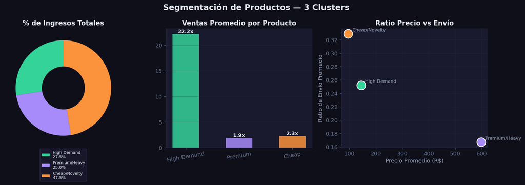

```python
# Clusters Productos
prod_names = {0: 'Cheap/Novelty', 1: 'Premium/Heavy', 2: 'High Demand'}
if 'cluster_name' not in products.columns:
    products['cluster_name'] = products['cluster'].map(prod_names)

prod_summary = products.groupby('cluster_name')['total_revenue'].agg(
    ['sum','mean','count']).round(2)
prod_summary['pct_products'] = (prod_summary['count'] / prod_summary['count'].sum() * 100).round(1)
prod_summary['pct_revenue']  = (prod_summary['sum']   / prod_summary['sum'].sum()   * 100).round(1)

prod_order      = ['High Demand', 'Premium/Heavy', 'Cheap/Novelty']
prod_colors_map = {'High Demand': GREEN, 'Premium/Heavy': PURPLE, 'Cheap/Novelty': ORANGE}

fig, axes = plt.subplots(1, 3, figsize=(15, 5))
fig.suptitle('Segmentación de Productos — 3 Clusters', fontsize=16,
             fontweight='bold', color='#e2e8f0')

# Dona Ingresos
rev_vals = [prod_summary.loc[c, 'pct_revenue'] if c in prod_summary.index else 0 for c in prod_order]
wedges, _ = axes[0].pie(
    rev_vals,
    colors=[prod_colors_map[c] for c in prod_order],
    startangle=90, wedgeprops=dict(width=0.55)
)
axes[0].set_title('% de Ingresos Totales', fontweight='bold')
axes[0].legend(wedges, [f'{c}\n{v:.1f}%' for c, v in zip(prod_order, rev_vals)],
               loc='lower center', bbox_to_anchor=(0.5, -0.3),
               fontsize=8, facecolor='#1a1a2e', edgecolor='#2d2d4e')

# Barras venta promedio
avg_sales = products.groupby('cluster_name')['total_sales'].mean()
vals = [avg_sales.get(c, 0) for c in prod_order]
bars = axes[1].bar(prod_order, vals,
                   color=[prod_colors_map[c] for c in prod_order],
                   alpha=0.85, width=0.5)
axes[1].set_title('Ventas Promedio por Producto', fontweight='bold')
axes[1].set_xticklabels([c.split('/')[0] for c in prod_order], rotation=10)
for bar, val in zip(bars, vals):
    axes[1].text(bar.get_x() + bar.get_width()/2, bar.get_height() + 0.2,
                 f'{val:.1f}x', ha='center', fontsize=10, fontweight='bold',
                 color='#e2e8f0')
axes[1].yaxis.grid(True, alpha=0.3)

# scatter precio vs envio
avg_metrics = products.groupby('cluster_name')[['avg_price', 'avg_freight_ratio']].mean()
for c in prod_order:
    if c in avg_metrics.index:
        axes[2].scatter(avg_metrics.loc[c, 'avg_price'],
                        avg_metrics.loc[c, 'avg_freight_ratio'],
                        color=prod_colors_map[c], s=300, zorder=5,
                        label=c, edgecolors='white', linewidth=1.5)
        axes[2].annotate(c, (avg_metrics.loc[c, 'avg_price'],
                             avg_metrics.loc[c, 'avg_freight_ratio']),
                         textcoords='offset points', xytext=(8, 5),
                         fontsize=9, color='#94a3b8')
axes[2].set_title('Ratio Precio vs Envío', fontweight='bold')
axes[2].set_xlabel('Precio Promedio (R$)')
axes[2].set_ylabel('Ratio de Envío Promedio')
axes[2].yaxis.grid(True, alpha=0.3)
axes[2].xaxis.grid(True, alpha=0.3)

plt.tight_layout()
plt.savefig('results/fig_product_clusters.png', dpi=150, bbox_inches='tight',
            facecolor='#0f0f1a')
plt.show()
```

### 💡 Insights de Productos

[output not shown]

```python
# Resumen clusters de productos
prod_summary['avg_sales'] = products.groupby('cluster')['total_sales'].mean().round(1)
prod_summary = prod_summary.sort_values('pct_revenue', ascending=False)

avg_price_by_cluster = products.groupby('cluster')['avg_price'].mean()

display_prod = prod_summary[['count', 'pct_products', 'sum', 'pct_revenue', 'avg_sales']].copy()
display_prod['avg_price'] = avg_price_by_cluster

display_prod.columns = ['# Productos', '% Productos', 'Ingresos Totales (R$)', '% Ingresos', 'Ventas Promedio', 'Precio Promedio (R$)']
display_prod['Ingresos Totales (R$)']  = display_prod['Ingresos Totales (R$)'].map('${:,.0f}'.format)
display_prod['Precio Promedio (R$)']   = display_prod['Precio Promedio (R$)'].map('${:,.0f}'.format)
display_prod['# Productos']           = display_prod['# Productos'].map('{:,.0f}'.format)
display_prod['% Productos']           = display_prod['% Productos'].map('{:.1f}%'.format)
display_prod['% Ingresos']            = display_prod['% Ingresos'].map('{:.1f}%'.format)
display_prod['Ventas Promedio']       = display_prod['Ventas Promedio'].map('{:.1f}'.format)

display_prod.style.set_table_styles([
    {'selector': 'th', 'props': [('background-color', '#1a1a2e'), ('color', '#fb923c'),
                                  ('font-weight', 'bold'), ('padding', '8px 12px')]},
    {'selector': 'td', 'props': [('background-color', '#0f0f1a'), ('color', '#e2e8f0'),
                                  ('padding', '8px 12px'), ('border-bottom', '1px solid #2d2d4e')]},
])
```

| cluster_name | # Productos | % Productos | Ingresos Totales (R$) | % Ingresos | Ventas Promedio | Precio Promedio (R$) |
| --- | --- | --- | --- | --- | --- | --- |
| Cheap/Novelty | 28,393 | 88.1% | $5,466,868 | 47.5% | nan | $nan |
| High Demand | 1,242 | 3.9% | $3,163,036 | 27.5% | nan | $nan |
| Premium/Heavy | 2,579 | 8.0% | $2,869,439 | 25.0% | nan | $nan |

## 🔗 Sección 5 — La Imagen Completa

Conectar los clusters de clientes, vendedores y productos revela patrones consistentes a través de los tres análisis.

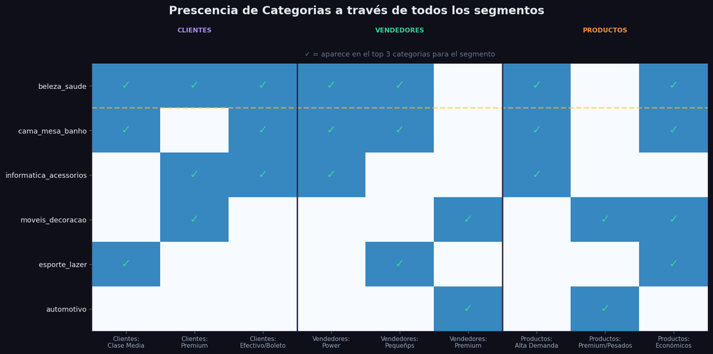

```python
# Categoria en todas las segmentaciones
fig, ax = plt.subplots(figsize=(14, 7))
fig.suptitle('Prescencia de Categorias a través de todos los segmentos', fontsize=16,
             fontweight='bold', color='#e2e8f0')

categories = ['beleza_saude', 'cama_mesa_banho', 'informatica_acessorios',
              'moveis_decoracao', 'esporte_lazer', 'automotivo']

# Matriz de prescencia
segments = [
    'Clientes:\nClase Media', 'Clientes:\nPremium', 'Clientes:\nEfectivo/Boleto',
    'Vendedores:\nPower', 'Vendedores:\nPequeñps', 'Vendedores:\nPremium',
    'Productos:\nAlta Demanda', 'Productos:\nPremium/Pesados', 'Productos:\nEconómicos'
]

presence = np.array([
    # bel  cam  inf  mov  esp  aut
    [1,    1,   0,   0,   1,   0],  # Cust Middle
    [1,    0,   1,   1,   0,   0],  # Cust Premium
    [1,    1,   1,   0,   0,   0],  # Cust Cash
    [1,    1,   1,   0,   0,   0],  # Sell Power
    [1,    1,   0,   0,   1,   0],  # Sell Small
    [0,    0,   0,   1,   0,   1],  # Sell Premium
    [1,    1,   1,   0,   0,   0],  # Prod High Demand
    [0,    0,   0,   1,   0,   1],  # Prod Premium
    [1,    1,   0,   1,   1,   0],  # Prod Cheap
])

im = ax.imshow(presence.T, cmap='Blues', aspect='auto', vmin=0, vmax=1.5)

ax.set_xticks(range(len(segments)))
ax.set_xticklabels(segments, fontsize=8.5, color='#94a3b8')
ax.set_yticks(range(len(categories)))
ax.set_yticklabels(categories, fontsize=10, color='#e2e8f0')

for i in range(len(segments)):
    for j in range(len(categories)):
        if presence[i, j] == 1:
            ax.text(i, j, '✓', ha='center', va='center',
                    fontsize=16, color=GREEN, fontweight='bold')

# Resaltar categoria importante beleza_saude
ax.axhline(-0.5, color='#fbbf24', lw=0.5, alpha=0.3)
ax.axhline(0.5, color='#fbbf24', lw=2, alpha=0.6, linestyle='--')

ax.set_title('✓ = aparece en el top 3 categorias para el segmento',
             fontsize=10, color='#64748b', pad=10)

# Divisores por seccion
ax.axvline(2.5, color='#2d2d4e', lw=2)
ax.axvline(5.5, color='#2d2d4e', lw=2)
ax.text(1, -1.2, 'CLIENTES', ha='center', color='#a78bfa', fontsize=9, fontweight='bold')
ax.text(4, -1.2, 'VENDEDORES', ha='center', color='#34d399', fontsize=9, fontweight='bold')
ax.text(7, -1.2, 'PRODUCTOS', ha='center', color='#fb923c', fontsize=9, fontweight='bold')

plt.tight_layout()
plt.savefig('results/fig_connected_picture.png', dpi=150, bbox_inches='tight',
            facecolor='#0f0f1a')
plt.show()
```

### 🔑 Hallazgos Transversales

#### 📈 La Palanca de Crecimiento

Los Pequeños Vendedores (89% del total) tienen excelentes reseñas pero bajo volumen. Los Power Sellers dominan informática y cama_mesa_banho. Convertir el 10% de Pequeños en Power Sellers = enorme potencial de ingresos.

#### 💳 Método de Pago = Proxy de Segmento

El método de pago es la señal de segmentación más fuerte — más que el nivel de gasto. Los usuarios de boleto y los de tarjeta de crédito son audiencias fundamentalmente distintas.

## 🎯 Recomendaciones Estratégicas para Olist

#### 🥇 Prioridad 1 Proteger a los Power Sellers

127 vendedores = 39% de los ingresos. Asignar gestores de cuenta dedicados. Cualquier pérdida aquí es catastrófica.

#### 🥉 Prioridad 3 Escalar la Clase Media

67k clientes ya usan tarjeta de crédito. Más opciones de cuotas en productos de mayor valor podría u opciones sin intereses podría convertirlos en Premium.

#### 📦 Prioridad 4 Convertir Pequeños Vendedores

Excelentes reseñas pero baja visibilidad. Mejorar calidad de listados, SEO interno y programa de aseroria basado en Power Sellers.

#### 💳 Prioridad 6 Desbloquear Pagadores en Efectivo

20% de los clientes limitados en gasto por restricciones de pago. Cuotas con boleto/efectivo + descuentos en envíos podrían desbloquear ingresos significativos.

Analysis basado en Olist Brazilian E-Commerce Dataset (2016–2018) · K-Means Clustering · Python / scikit-learn  
Datasets: orders · items · payments · customers · reviews · sellers · products · geolocation